# Forecasting the Outbreak of Zika with Indirect Data Sources

Taneisha Arora, Tristan Dam

June 8, 2020

## 1. Exploratory Data Analysis

We collected cumulative weekly case counts of the Zika Virus over the course of the years **2015, 2016, and 2017**. The case counts we collected were from the **Brazil**, the country where the first confirmed case was reported in May 2015, and the **United States**.

Our primary goal is to be able to forecast the number of Zika Cases that will be reported in the United States in the following week. In other words, using data from weeks 1 to N-1, predict the number of new cases in week N. So, our “Y” is the number of Zika cases reported in the United States in a given week. Before beginning the modelling process we will need to:

1.1 Check for Anomoulous Data Points  
1.2 Establish Stationarity  
1.3 Explore which Features could be Associated with Weekly US Zika Case Counts  
1.4 Determine whether there is Autocorrelation and/or Cross-correlation

### 1.1 Check for Anomoulous Data Points

Before deving into visualizations, we will take a look at our raw data. This is to check for any anomalyous values such as negative case counts. For this purpose we will query the `brazil_counts` and `observed` columns in our preprocessed dataset. We do not check the other fields as those were derived from our original data sources (Twitter/Reddit databases) and have, so, been preprocessed.

| rowid | brazil_counts | observed |
| --- | --- | --- |
| 123 | 1039 | -38 |

We see that in row 123 (which corresponds to week 123 since the data frame is ordered by week number) the number of observed cases in the United States is -38. This could either be a decrease in cases from the previous week, or simply an error. We could either impute the mean of the case counts of the previous and the next weeks, which would suggest that the number of new cases in week 123 was similart to those observed in the weeks immediately following and preceding it. Alternatively, the negative value could have arisen from a decrease in cumulative cases in week 123 relative to week 122. This interpretation suggests that the number of new cases reported in week 123 was zero

We will impute the negative value with the mean case count for weeks 122 and 124.

### 1.2 Establishing Stationarity

Having scrubbed the data for any invalid values, we will now create some time series plots to visualize how the number of reported Zika cases in the United States varies over time. We will first perform a qualitative check by looking for patterns in the time series plot, followed by a more formal Unit Root test, to determine whether our data is stationary or not, and if differencing is required..

#### 1.2.a Qualitative Scan

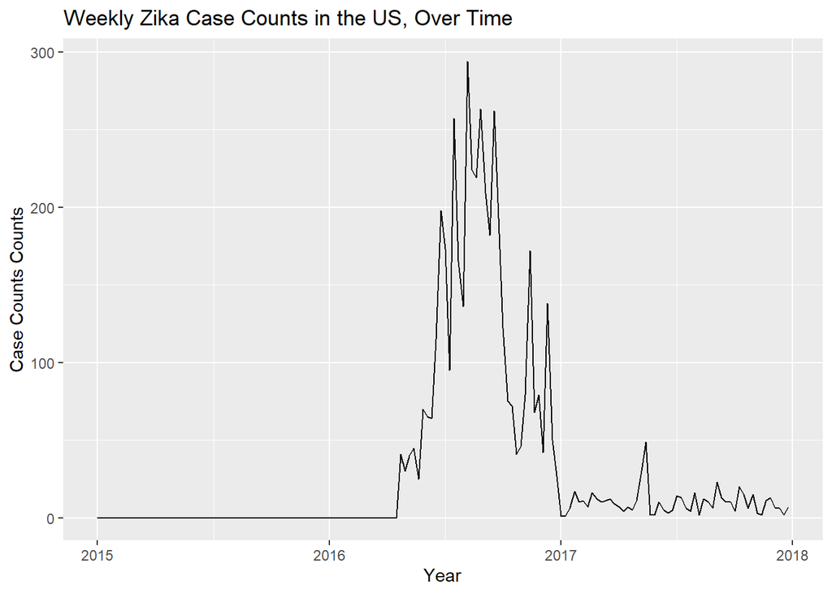

We see a peak in cases a few months into 2016. The case counts decrease, progressing into 2017. Since the data does not look random at every time point, but rather shows a distinctive pattern (peak/fall), we suspect our data is **non-stationary**.

#### 1.2.b Unit Root Test

The high level hypotheses of the Unit Root test are:

$H_0 : The\;data\;is\;stationary$  
$H_a: The\;data\;is\;not\;stationary$

```
##
## #######################
## # KPSS Unit Root Test #
## #######################
##
## Test is of type: mu with 4 lags.
##
## Value of test-statistic is: 0.4374
##
## Critical value for a significance level of:
##                 10pct  5pct 2.5pct  1pct
## critical values 0.347 0.463  0.574 0.739
```

Here is a visualziaion of the first differenced Weekly US case counts:

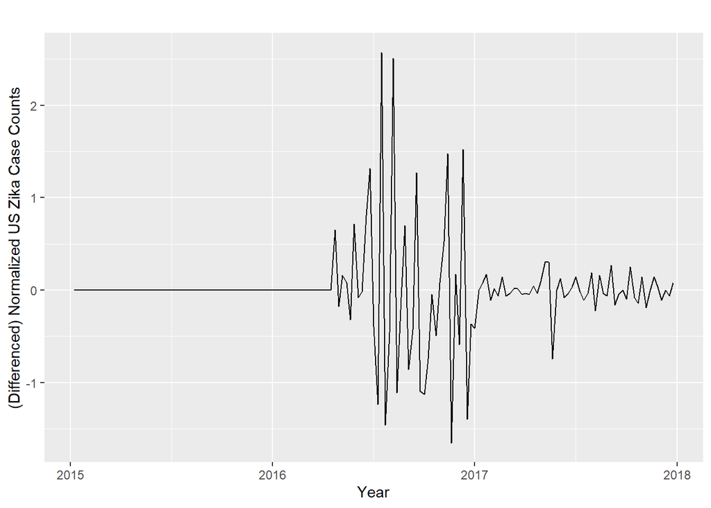

### 1.3 Explore which Features could be Associated with Weekly US Zika Case Counts

Now we will plot some of our weekly features along with the Weekly US Zika Case counts to see how certain features that follow the trend of the Zika cases reported in the US

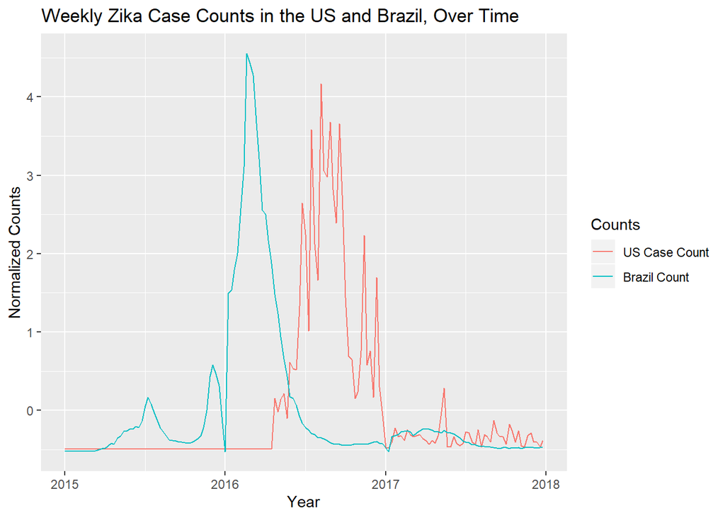

**Observations:** We see that the Zika cases in Brazil peak in early 2016. This is before the peak in the United States, and so, case counts from Brazil, lagged by a few weeks, could potentially be useful in the forecasting of cases in the US.

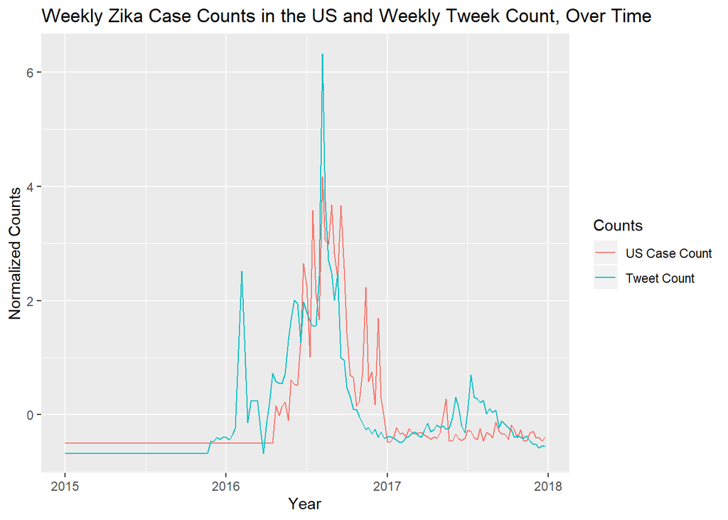

**Observations:** We see that the Zika cases in the United States align fairly well with the number of weekly tweets containing Zika-related keywords. Theser is a small spike seen in the earlier weeks of 2016, that might correspond to the outbreak of the virus in Brazil.

[figure not shown]

**Observations:** The number of reddit submissions and comments pertaining to the Zika virus also follows trends similar to the US case counts. However, an interesting thing to note is that, given that the reddit data is not restricted to users in the United States, the Zika-related activity shows a much higher peak around the time the virus outbroke in Brazil compared to the chatter on Twitter, that was limited to the US.

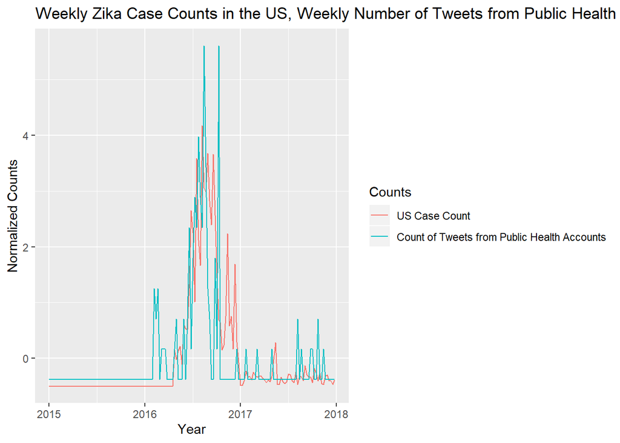

**Observations:** Although there weren’t too many tweets shared by public health accounts, upon normalization, the chatter amongst thepublic health community adheres fairly well to the US case count trends.

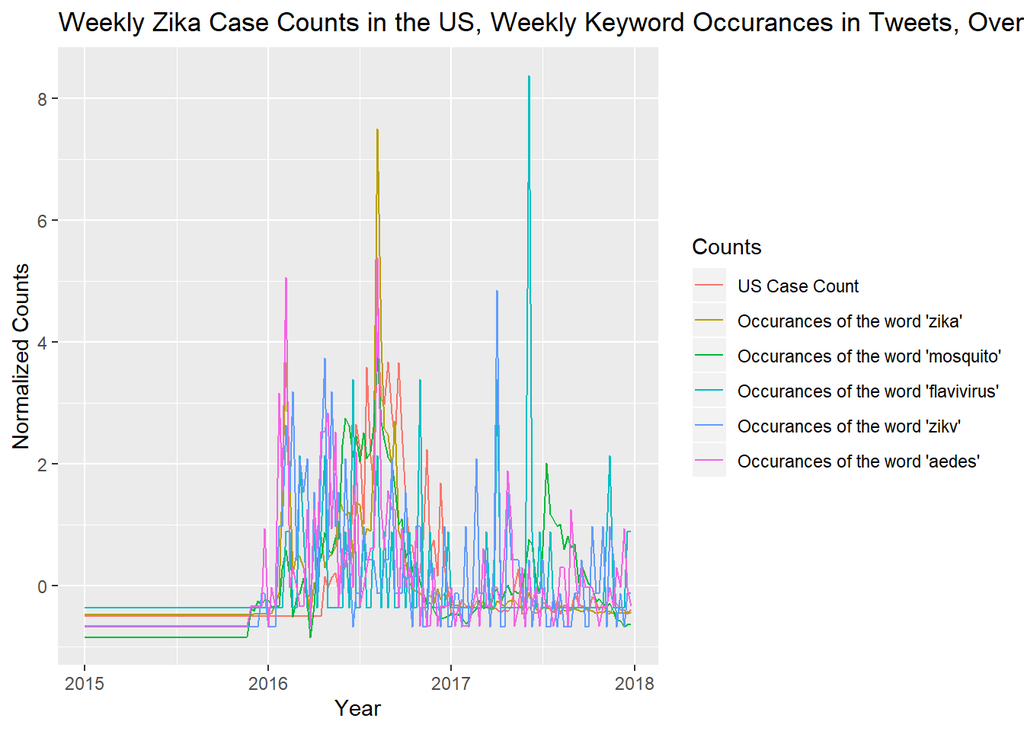

**Observations:** Rarely occuring keywords like ‘flavivirus’ and ‘aedes’ seem to follow very noisy trends. The more abundant ones such as ‘zika’ and ‘mosquito’ follow trends similar to those seeen for overall tweet counts. This might be because a majoirty of the Zika-related tweets contain those two words.

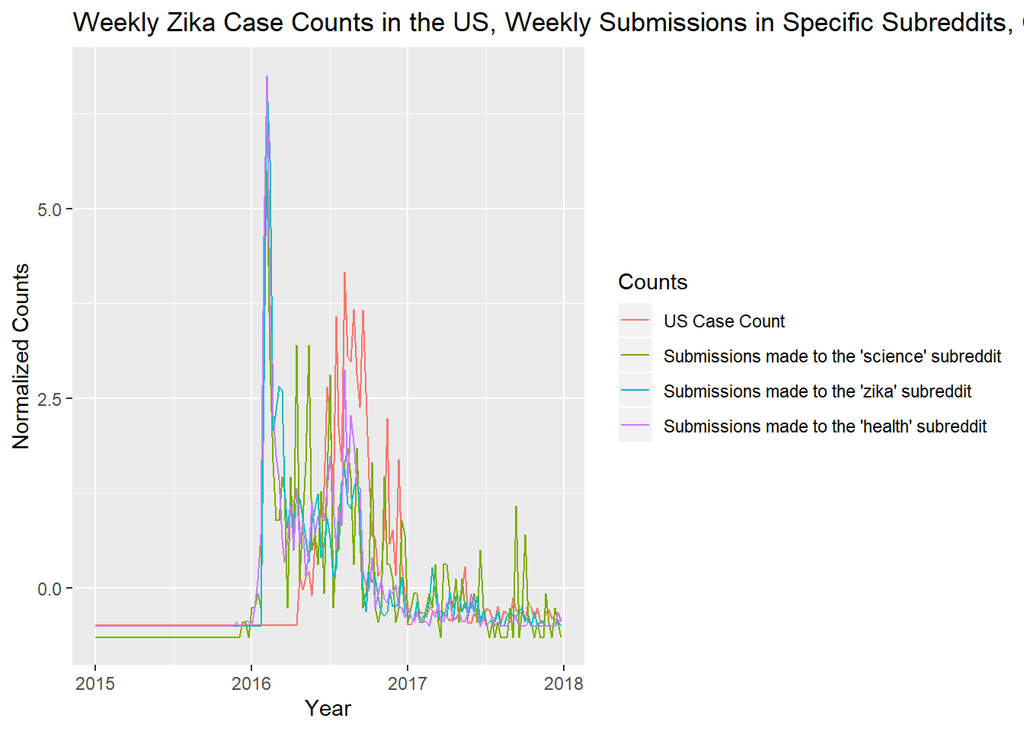

**Observations:** The number of reddit submissions made to the ‘science’ subreddit seems to **precede** the trend the US case counts is about to follow. This suggests, that a lagged predictor for the number of ‘sicence’ submissions might be useful in predicting US case counts.

#### 1.4 Determine whether there is Autocorrelation and/or Cross-correlation

##### 1.4.a Autocorrelation

We will use autocorrelation plots to determine case counts from how many weeks prior is most correlated to the ‘present’ number of case counts. In other words, this will help us determine whether we can leverage past case counts to predict future case counts. To check for autocorrelation, we will first perform a qualitative scan of our first differenced Weekly US cases counts.

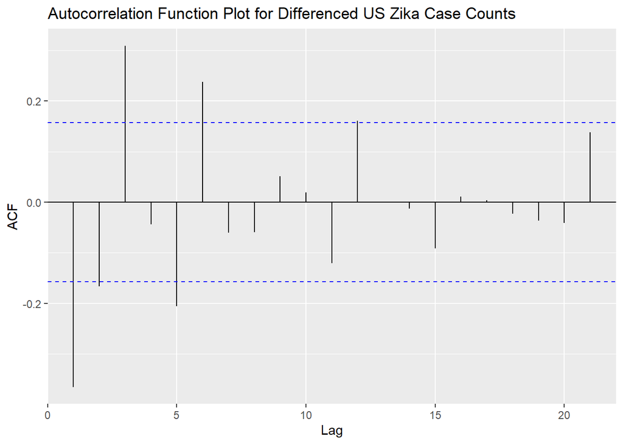

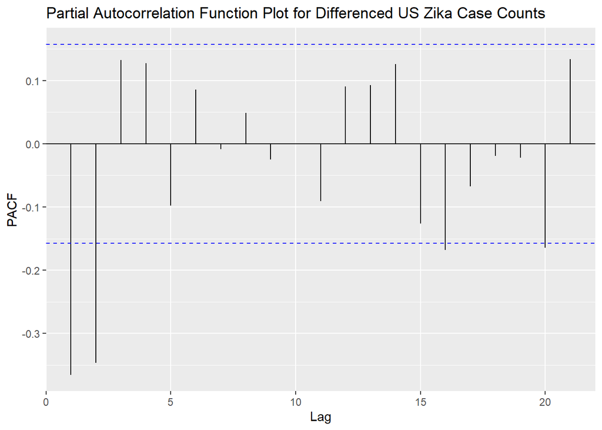

**Observations:** Case counts from *1*, *2*, and *3* weeks ago seem to be most correlated with the ‘current’ case count. This is suggests that lag terms of 1, 2, and 3 might be worth trying out.

##### 1.4.b Cross-correlation

The timeseries plots that showed how the trends of our other features compared to the observed number of weekly cases of Zika in the US suggested that there might be some correlation between these other timeseries and the US Zika case count time series. To check for lagged correlations between the US Zika case counts and the other (time dependent) features in our dataset, we will check the cross-correlation. Based off of our earlier timeseries plots, it seemed like the following features could potentially be cross correlated with the Weekly Case Counts of the zika Virus in the US:

- Brazil Case Counts
- Tweet Counts
- Reddit Submissions/Comments
- Number of Tweets from Public Health Accounts

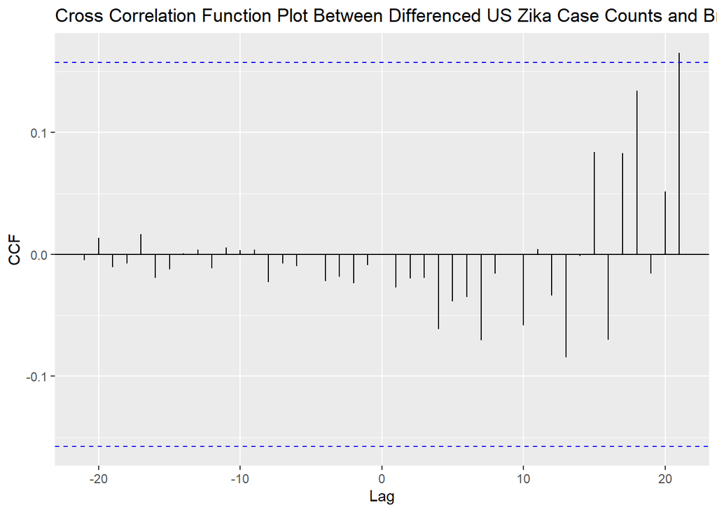

**Observations:** It seems like case counts in Brazil reported 20 weeks (or 5 months) earlier have some correlation with the current number of cases in the US.

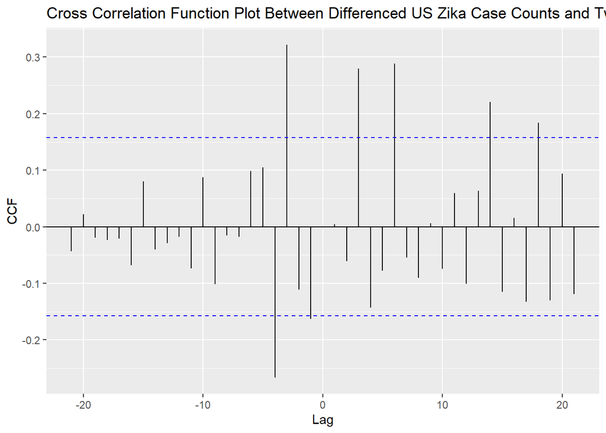

**Observations:** We see both positive and negativ lag terms that are significant for Tweet counts. The negative lag terms suggest that the Tweets appear **after** the cases are reported. However, it also appears that Tweet counts from 3 or 6 weeks before may be relevant in predicting the number of reported cases in the current week.

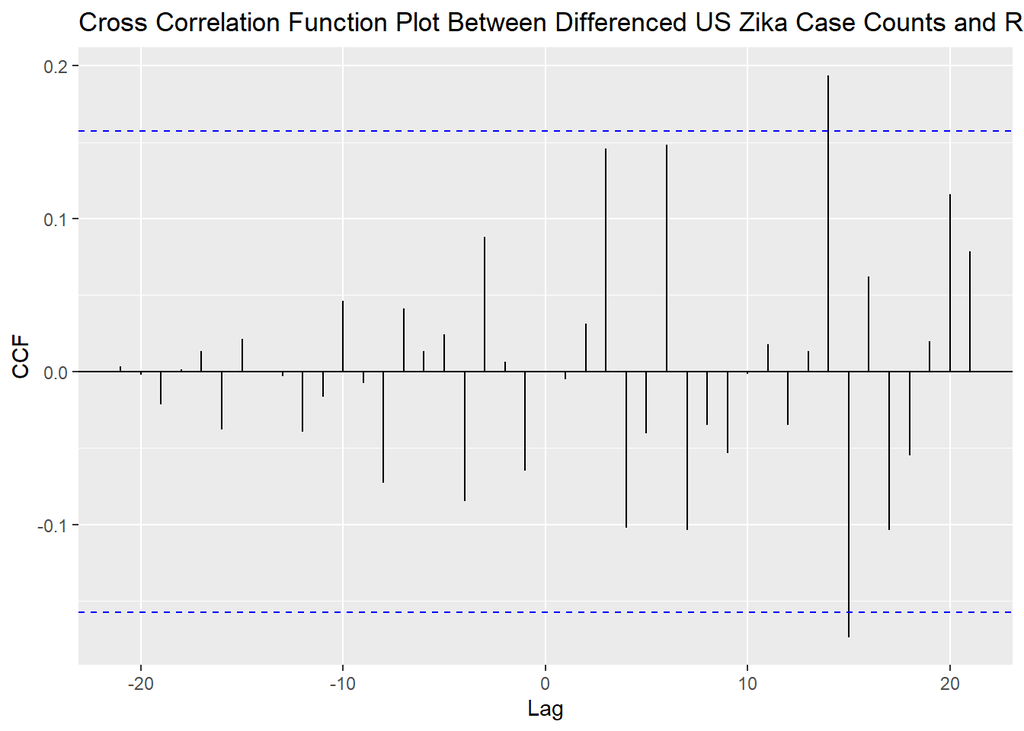

**Observations:** It appears that the number of reddit submissions from 14 weeks prior might be relevant in preicting reported cases of Zika.

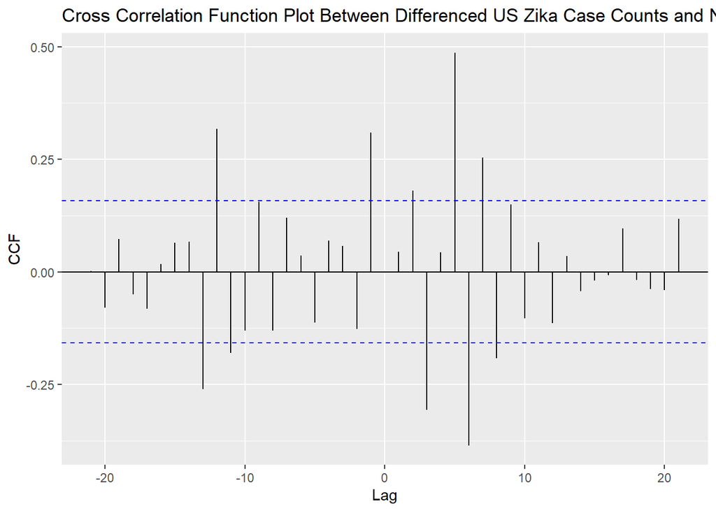

## 2. Modelling

Now that we have established a reasonable understanding of our data and how various features are/could be associated with our outcome variable, Weekly Reported Cases of Zika in the US, we can begin trying out different models.

### Purely Autoregressive Models

#### ARIMA(1,1)

```
## Series: ts_obj[53:104, "observed"]
## ARIMA(1,1,0)
##
## Coefficients:
##           ar1
##       -0.3682
## s.e.   0.1285
##
## sigma^2 estimated as 2588:  log likelihood=-272.33
## AIC=548.66   AICc=548.91   BIC=552.52
##
## Training set error measures:
##                    ME   RMSE      MAE       MPE    MAPE      MASE       ACF1
## Training set 0.873226 49.886 33.05329 -14.27063 49.1424 0.9328819 -0.1463382
```

#### ARIMA(2,1)

```
## Series: ts_obj[53:104, "observed"]
## ARIMA(2,1,0)
##
## Coefficients:
##           ar1      ar2
##       -0.5226  -0.3903
## s.e.   0.1296   0.1305
##
## sigma^2 estimated as 2237:  log likelihood=-268.27
## AIC=542.54   AICc=543.05   BIC=548.34
##
## Training set error measures:
##                    ME     RMSE      MAE       MPE    MAPE      MASE      ACF1
## Training set 2.057689 45.91587 30.64035 -12.02047 49.4707 0.8647802 0.0487127
```

#### ARIMA(3,1)

```
## Series: ts_obj[53:104, "observed"]
## ARIMA(3,1,0)
##
## Coefficients:
##           ar1      ar2     ar3
##       -0.4618  -0.3074  0.1629
## s.e.   0.1379   0.1471  0.1401
##
## sigma^2 estimated as 2222:  log likelihood=-267.61
## AIC=543.21   AICc=544.08   BIC=550.94
##
## Training set error measures:
##                    ME     RMSE      MAE      MPE     MAPE      MASE        ACF1
## Training set 1.647604 45.28377 29.36957 -11.8323 47.09888 0.8289142 -0.03497433
```

Amongst the three, purely autoregressive models we tried, the models with lags of 2 and 3 weeks seem to perform better than the model where the lag is set to 1 week. The AIC value is the smallest for the `ARIMA(2, 1)` model, while the root mean squared error (RMSE) is lowest for the `ARIMA(3,1)` model. The RMSE can be interpretted as the number of cases our prediction was off by on average.

We decided to proceed to use the Weekly Zika Case Counts for time **T-3** to predict the cases at time **T**

#### Autoregressive Models with (lagged) covariates

- Weekly cases in Brazil
- Weekly Reddit submission count
- Weekly Tweet count
- Weekly number of Tweets shared by Public Health related accounts
- Weekly count of submissions made to Science subreddit

We will first experiment with how these different covariates influence the RMSE and improve or worsen our predictive performance.

#### ARIMA(3,1) + Brazil Case Count

```
## Series: ts_obj[53:104, "observed"]
## Regression with ARIMA(3,1,0) errors
##
## Coefficients:
##           ar1      ar2     ar3     xreg
##       -0.4674  -0.3140  0.1572  -0.0013
## s.e.   0.1383   0.1477  0.1407   0.0028
##
## sigma^2 estimated as 2260:  log likelihood=-267.51
## AIC=545.01   AICc=546.34   BIC=554.67
##
## Training set error measures:
##                    ME     RMSE    MAE MPE MAPE     MASE        ACF1
## Training set 1.648406 45.19274 30.451 NaN  Inf 0.859436 -0.03288598
```

#### ARIMA(3,1) + Tweet Count

```
## Series: ts_obj[53:104, "observed"]
## Regression with ARIMA(3,1,0) errors
##
## Coefficients:
##           ar1      ar2     ar3    xreg
##       -0.5045  -0.3601  0.0392  0.0154
## s.e.   0.1409   0.1528  0.1718  0.0107
##
## sigma^2 estimated as 2178:  log likelihood=-266.52
## AIC=543.04   AICc=544.37   BIC=552.7
##
## Training set error measures:
##                    ME     RMSE      MAE MPE MAPE      MASE        ACF1
## Training set 1.918823 44.37348 31.77811 NaN  Inf 0.8968918 -0.01782384
```

#### ARIMA(3,1) + Reddit Science Submissions

```
## Series: ts_obj[53:104, "observed"]
## Regression with ARIMA(3,1,0) errors
##
## Coefficients:
##           ar1      ar2     ar3    xreg
##       -0.4623  -0.3088  0.1617  0.0451
## s.e.   0.1382   0.1495  0.1422  0.8821
##
## sigma^2 estimated as 2269:  log likelihood=-267.61
## AIC=545.21   AICc=546.54   BIC=554.87
##
## Training set error measures:
##                    ME     RMSE      MAE MPE MAPE      MASE        ACF1
## Training set 1.645684 45.28258 29.45327 NaN  Inf 0.8312766 -0.03514012
```

#### ARIMA(3,1) + Public Health Account Tweets

```
## Series: ts_obj[53:104, "observed"]
## Regression with ARIMA(3,1,0) errors
##
## Coefficients:
##           ar1      ar2     ar3     xreg
##       -0.4348  -0.2924  0.1684  -1.7574
## s.e.   0.1426   0.1476  0.1402   2.5363
##
## sigma^2 estimated as 2249:  log likelihood=-267.37
## AIC=544.74   AICc=546.07   BIC=554.4
##
## Training set error measures:
##                    ME     RMSE      MAE MPE MAPE      MASE        ACF1
## Training set 1.592054 45.08974 30.45179 NaN  Inf 0.8594583 -0.03323281
```

From the above models, where all we changed was the covariate included, it seems like the ARIMA(3,1) model with Tweet count and Public Health Tweet count had the lowest AIC values of **543.04** and **544.74**, respectively. Corresponding RMSE values for these two models is also relatively lower than the other models tried out in this section.

It will be interesting to see if we can improve our prediction by incorporating both these covariates into a single model

#### ARIMA(3,1) + Tweet Count + Public Health Account Tweets

```
## Series: ts_obj[53:104, "observed"]
## Regression with ARIMA(3,1,0) errors
##
## Coefficients:
##           ar1      ar2     ar3  tweet_count  ph_account_counts
##       -0.4790  -0.3514  0.0297       0.0166            -2.1360
## s.e.   0.1442   0.1533  0.1770       0.0111             2.5339
##
## sigma^2 estimated as 2197:  log likelihood=-266.17
## AIC=544.34   AICc=546.25   BIC=555.93
##
## Training set error measures:
##                    ME     RMSE     MAE MPE MAPE      MASE        ACF1
## Training set 1.898218 44.08613 32.2985 NaN  Inf 0.9115792 -0.01546789
```

This model that incorporates both, the Tweet Count and Number of Tweets shared by Public Health accounts has the lowest RMSE value we’ve observed so far (**44.086**)!

Now we will experiment with the lags of these shortlisted features to see if our model can be made even better.

##### Setting up some lagged covariates.

```r
lagged_predictors <- cbind(
  lagged_brazil_counts = stats::lag(ts_obj[,"brazil_counts"], -20), # lag of 8 because cases in Brazil began to appear about 2 months prior to when they started popping up in the US
  lagged_ph_accounts = stats::lag(ts_obj[,"ph_account_counts"], -2), # based on CCF
  lagged_tweet_counts = stats::lag(ts_obj[, "tweet_count"], -5), # based on CCF
  lagged_submission_counts = stats::lag(ts_obj[, "submission_count"], -14) # based on CCF
)
```

#### ARIMA(3,1) + Tweet Count + Public Health Account Tweets + Lagged Brazil Case Counts + Lagged Reddit Submissions

```
## Series: ts_obj[53:104, "observed"]
## Regression with ARIMA(3,1,0) errors
##
## Coefficients:
##           ar1      ar2      ar3  tweet_count  ph_account_counts  brazil_cases
##       -0.5374  -0.4176  -0.0439       0.0175            -2.3153        0.0042
## s.e.   0.1443   0.1542   0.1798       0.0108             2.5104        0.0025
##       reddit_submissions
##                   0.0137
## s.e.              0.0158
##
## sigma^2 estimated as 2179:  log likelihood=-264.86
## AIC=545.71   AICc=549.14   BIC=561.17
##
## Training set error measures:
##                    ME     RMSE      MAE MPE MAPE      MASE         ACF1
## Training set 2.024742 42.93822 31.10807 NaN  Inf 0.8779808 -0.009186243
```

Looks like adding in the lagged Brazil case counts and and Reddit submissions improved our model by further reducing the RMSE down to **42.93822**!

So here is our final model:

$Y_t = \beta_0+\beta_1*Y_{t-1}+\beta_2*Y_{t-2}+\beta_3*Y_{t-3}+\beta_4*X_1+\beta_5*X_2+\beta_6*X_3+\beta_7*X_4$

Where,  
$Y_t$ is the number of cases of Zika in the US in week $t$  
$Y_t-1$ is the number of cases of Zika in the US in week $t-1$  
$Y_t-2$ is the number of cases of Zika in the US in week $t-2$  
$Y_t-3$ is the number of cases of Zika in the US in week $t-3$  
$X_1$ is the number of Zika related Tweets shared in week $t$  
$X_2$ is the number of Zika related Tweets shared by Public Health Accounts the US in week $t$  
$X_3$ is the number of cases of Zika in Brazil in week $t-20$  
$X_4$ is the number of Zika related submissions made to Reddit in week $t-14$

# 3. Evaluation

We evaluate the performance of our final model by:

1. Visually assessing how well the predicted trend fits the actual trend
2. Computing the one-step-ahead prediction error

### 1. Qualitiative Assessment

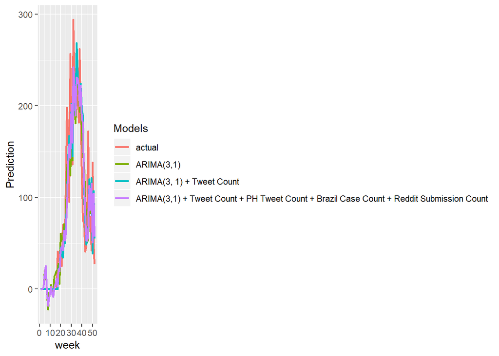

### 2. Evaluating Metrics

The metrics we compared to assess the various models we tried were:

- Root Mean Squared Error (RMSE)
- A Modified Version of the $R^2$
- Akaike’s Information Criterion (AIC)

#### RMSE

The Root Mean Squared Error for each model was computed as follows:

To compute the **one step ahead** prediction/error, we set $h = 1$. We interpret the RMSE as the average number of case counts our prediction was off by.

#### Modified $R^2$

We computed the $R^2$ values for the ARIMA models as the correlation between the fitted and the predicte values. We interpret this modified version of the $R^2$ as the total approximate variance in the number of predicted weekly case counts explained by the model.

All the evaluation metrics, except the modified $R^2$ are printed in the model summaries above. Here are the values of the modified $R^2$ for the models we tried:

```
## [1] 0.6873999
```

```
## [1] 0.7438748
```

```
## [1] 0.7557308
```

# 4. Prediction

Given the number of Tweets shared, Tweets made by public health affiliated accounts, case counts of Zika reported 20 weeks ago, and number of Zika related submissions made 14 weeks ago, we can predict the number of potential occurances of the Zika Virus in the United States in the current week.

### Example:

```
## [1] "Observed 65"
```

```
## [1] "Predicted 70.7279455224068"
```